# Lab 2

Author

Tuukka Jaakkola

Published

October 9, 2023

# LAB 2: Avocado Data

Load Packages and data

```python
import warnings
import numpy as np
import pandas as pd
from plotnine import ( ggplot,
                      aes,
                      geom_boxplot,
                      theme_bw,
                      geom_smooth,
                      facet_wrap,
                      geom_line,
                      geom_point,
                      labs,
                      ggtitle,
                      element_text,
                      guides,
                      guide_legend,
                      element_blank,
                      geom_bar,
                      scale_y_continuous,
                      scale_color_discrete,
                      geom_text,
                      theme)
```

```python
cado = pd.read_csv(r"C:\Users\tuke-\Desktop\1_GSB544_Computing_and_Machine_Learning\Week_2\LAB2\data\avocado-updated-2020.csv")
```

Using a for loop to categorize variables. (Chat GPT was used to troubleshoot/find the exact loop format)

```python
#for loop that checks if the calue in the gegraphy column is one of the values determined by me, it then assigns a value or moves on.
for i in cado.index:
    if cado.loc[i, 'geography'] in ['California', 'South Carolina', 'West Tex/New Mexico', 'Northern New England']:
        cado.loc[i, 'region_type'] = 'state'
    elif cado.loc[i, 'geography'] in ['Midsouth', 'Northeast', 'Southeast', 'West']:
        cado.loc[i, 'region_type'] = 'major'
    elif cado.loc[i, 'geography'] in ['Total U.S.']:
        cado.loc[i, 'region_type'] = 'us'
    else:
        cado.loc[i, 'region_type'] = 'metro'

# Renaming columns for avocado sizes, also renaming the year column ahead of following problems
cado = cado.rename(columns={'4046': 'small_hass',
                            '4225': 'large_hass',
                            '4770': 'xlarge_hass',
                           'year': '_year'})
```

From this point on, I am treating “cado” as the source file so I do not need to run through the above code again.

```python
avocado_clean = cado
```

### Question 3:

```python
#Filter data to include major region with organic avocados in 2017
avocado_major_organic_2017 = avocado_clean[(avocado_clean['region_type'] == 'major') &
                                        (avocado_clean['type'] == 'organic') &
                                        (avocado_clean['_year'] == 2017)]
#Take the sum of small hass based on grouping in mojor regions
avocado_major_organic_2017_sum = avocado_major_organic_2017.groupby('geography')['small_hass'].sum()

print('The highest sales for a major region were in the: ' + avocado_major_organic_2017_sum.idxmax())
```

```
The highest sales for a major region were in the: West
```

### Question 4:

```python
avocado_clean = cado

avocado_clean['date'] = pd.to_datetime(avocado_clean['date'])

#seperate into different columns
avocado_clean['year'] = avocado_clean['date'].dt.year
avocado_clean['month'] = avocado_clean['date'].dt.month
avocado_clean['day'] = avocado_clean['date'].dt.day

#delete date column
avocado_date = avocado_clean#.drop('date', axis = 1)

#take the sum for each month for each year
avocado_month_sum = avocado_date.groupby(['year', 'month'])['total_volume'].sum()

#take the max value of the average value of the month accross all years.
max_mean = avocado_month_sum.groupby('month').mean().idxmax()
print(f'The highest average avogado sales are in month {max_mean}')
```

```
The highest average avogado sales are in month 5
```

### Question 5:

```python
avocado_clean = avocado_date

#Filter data to include metro regions
avocado_metro = avocado_clean[(avocado_clean['region_type'] == 'metro')]

#Take the sum of volume in each geographical metro regions and reset the index
avocado_metro_sum = avocado_metro.groupby('geography')['total_volume'].sum().reset_index()

#Take the 5 highest regions
avocado_metro_top5 = avocado_metro_sum.nlargest(5,'total_volume')

#Convert to a list
#https://pandas.pydata.org/docs/reference/api/pandas.Series.tolist.html
avocado_metro_top5_list = avocado_metro_top5['geography'].tolist()

#Filter the dataframe to only include the top 5 metro volumes
avocado_metro_plot = avocado_clean[avocado_clean['geography'].isin(avocado_metro_top5_list)]
```

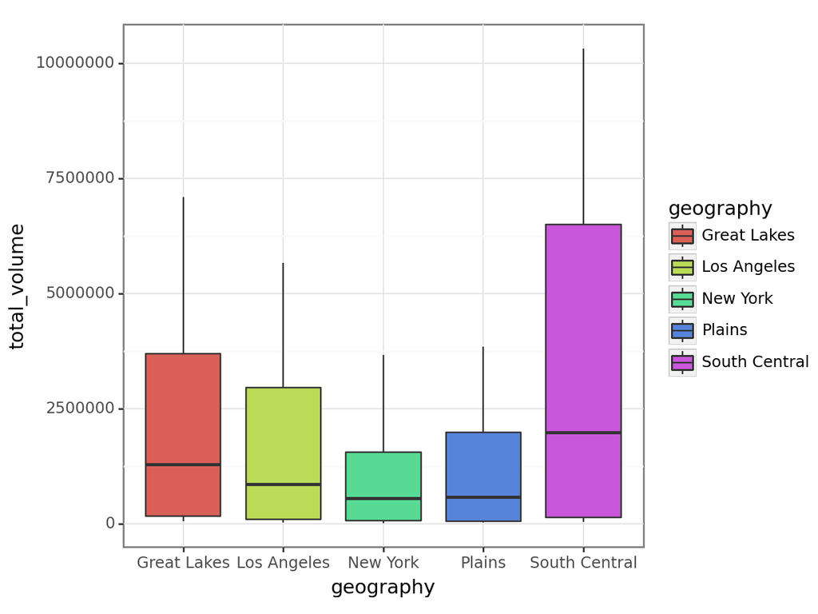

```
<Figure Size: (640 x 480)>
```

```python
#Plot
(ggplot(avocado_metro_plot) +
    theme_bw() +
    geom_boxplot(aes(x = 'geography', y = 'total_volume', fill = 'geography'))
)
```

### Question 6:

```python
avocado_clean = avocado_date

#Filter data to include the four cities
avocado_cali = avocado_clean[avocado_clean['geography'].isin(['Los Angeles', 'San Francisco', 'San Diego', 'Sacramento'])]
```

### Question 7:

```python
#Split data to conventional and organic
avocado_cali_conv = avocado_cali[(avocado_cali['type'] == 'conventional')]
avocado_cali_org = avocado_cali[(avocado_cali['type'] == 'organic')]

#Change price column names in preparation of joining data
avocado_cali_conv = avocado_cali_conv.rename(columns={'average_price': 'average_price_conv'})
avocado_cali_org = avocado_cali_org.rename(columns={'average_price': 'average_price_org'})

#Take the mean of each month of each year of each city
avocado_cali_conv_avg = avocado_cali_conv.groupby(['geography','year', 'month'])['average_price_conv'].mean().reset_index()
avocado_cali_org_avg = avocado_cali_org.groupby(['geography','year', 'month'])['average_price_org'].mean().reset_index()

#join organic and conventional to one data frame by city, year, and month
avocado_cali_merge = avocado_cali_conv_avg.merge(avocado_cali_org_avg, on = ['geography', 'year', 'month'])

#take the difference of the organic and conventional avocados for each index
avocado_cali_merge['price_delta'] = avocado_cali_merge['average_price_org'] - avocado_cali_merge['average_price_conv']

#merge the year and month column to allow for plotting
avocado_cali_merge['y_m'] = avocado_cali_merge['year'].astype(str) + '-' + avocado_cali_merge['month'].astype(str)

#convert the merged string into a datetime format for the plotter to understand.
avocado_cali_merge['y_m'] = pd.to_datetime(avocado_cali_merge['y_m'], format='%Y-%m')
```

#### Plotting

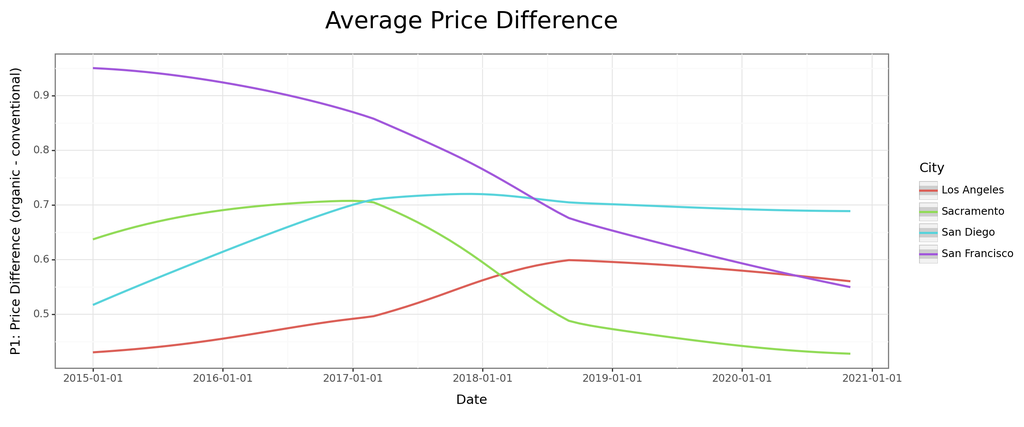

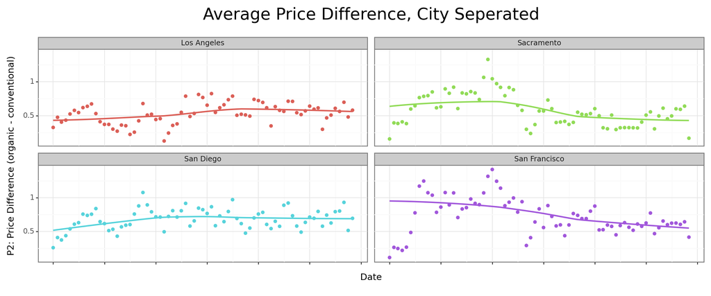

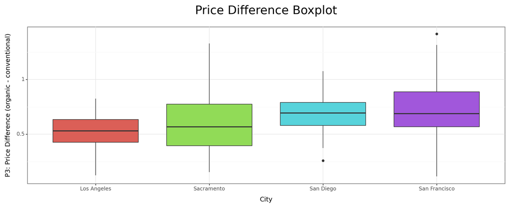

```python
warnings.filterwarnings('ignore')

plot1 = (ggplot(avocado_cali_merge,aes(x = 'y_m', y = 'price_delta', color = 'geography')) +
    theme_bw() +
    geom_smooth() +
    labs(x = 'Date', y = 'P1: Price Difference (organic - conventional)') +
    ggtitle('Average Price Difference') +
    guides(color = guide_legend(title = 'City')) +
    theme(
        figure_size = (12,5),
        plot_title = element_text(size = 20, hjust = 0.5))
)

plot2 = (ggplot(avocado_cali_merge,aes(x = 'y_m', y = 'price_delta', color = 'geography')) +
    theme_bw() +
    facet_wrap('geography') +
    geom_point() +
    geom_smooth() +
    labs(x = 'Date', y = 'P2: Price Difference (organic - conventional)') +
    ggtitle('Average Price Difference, City Seperated') +
    guides(color = False) +
    theme(
        figure_size = (12,5),
        plot_title = element_text(size = 20, hjust = 0.5),
        axis_text_x = element_blank())
)

plot3 = (ggplot(avocado_cali_merge,aes(x = 'geography', y = 'price_delta', fill = 'geography')) +
    theme_bw() +
    geom_boxplot() +
    labs(x = 'City', y = 'P3: Price Difference (organic - conventional)') +
    ggtitle('Price Difference Boxplot') +
    guides(fill = False) +
    theme(
        figure_size = (12,5),
        plot_title = element_text(size = 20, hjust = 0.5),
        )
)

print(plot1)
print(plot2)
print(plot3)
```

#### Plot Analysis:

The plots will give us a quick understanding, however, it does not offer the complete picture.

P1: We can see the trends that the different cities have had in their avocado price differences, mainly that San Francisco had large differences, however, it has evened out in the past few years. Although, this plot gives us insight in the relative trends of the different cities, it might not provide a complete picture, so another plot was created.

P2: this plot supports the conclusion that P1 was not enough to tell the complete picture. We can see that San Francisco and Sacramento have very similar patterns with a price difference hike late 2016 to early 2017, whereas Los angeles has, what looks like the most stable pattern.

#### Summary

```python
#Take the sum of price delta for each city
avocado_cali_delta_sum = avocado_cali_merge.groupby(['geography'])['price_delta'].sum().reset_index()

print(avocado_cali_delta_sum)

# take the sum of price delta for each city for the last two years of data
avocado_cali_delta_sum_19_20 = avocado_cali_merge[(avocado_cali_merge['year'].isin([2019, 2020]))]
avocado_cali_delta_sum_19_20 = avocado_cali_delta_sum_19_20.groupby(['geography'])['price_delta'].sum().reset_index()

print(avocado_cali_delta_sum_19_20)
```

```
       geography  price_delta
0    Los Angeles      37.5520
1     Sacramento      41.3085
2      San Diego      48.4520
3  San Francisco      51.3225
       geography  price_delta
0    Los Angeles      13.2510
1     Sacramento       9.9500
2      San Diego      16.0375
3  San Francisco      13.6110
```

What we can see with this data is that San Francisco is in fact the city with the largest price difference between organic and conventional avocados, however, it should be noted that in the last 2 years of data, San francisco has evened out and San Diego has become the city with the largest price difference.

### Question 8:

```python
#Is it just me or does this variable sound like a delicious sandwich.
#https://pandas.pydata.org/docs/reference/api/pandas.DataFrame.melt.html
avocado_cali_melt = avocado_cali.melt(value_vars = ['small_hass', 'large_hass', 'xlarge_hass'],
                                      var_name = 'size_type',
                                      value_name = 'volume',
                                      id_vars = ['geography', 'type'])

#Take the sum of volumns for each city and add make it into a column that matches the sum to the right city
#https://pandas.pydata.org/docs/reference/api/pandas.DataFrame.transform.html
total_volume = total_volume = avocado_cali_melt.groupby(['geography', 'type'])['volume'].transform('sum')

#calculate the percentage
avocado_cali_melt['percentage'] = avocado_cali_melt['volume'] / total_volume
```

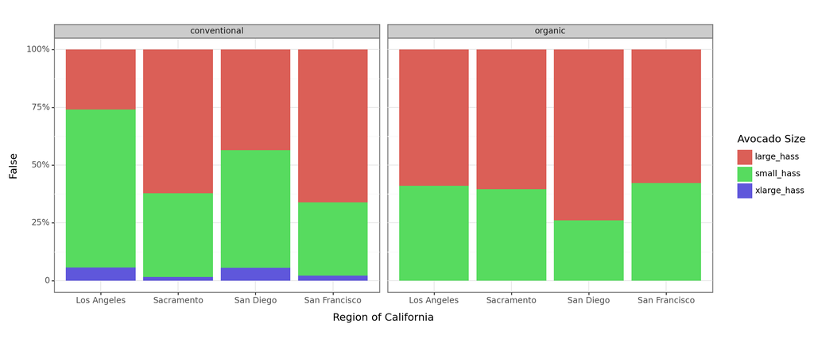

```
<Figure Size: (1200 x 500)>
```

```python
#plot
(ggplot(avocado_cali_melt, aes(x='geography', y = 'percentage', fill = 'size_type')) +
     theme_bw() +
     facet_wrap('type') +
     geom_bar(stat = 'identity') +
     scale_y_continuous(breaks = [0,0.25,0.5,0.75,1], labels = ['0', '25%', '50%', '75%', '100%']) +
     labs(x = 'Region of California', fill = 'Avocado Size', y = False) +
     theme(figure_size = (12,5))
)
```

## Outside Data

I did some excel editing to remove rows and make the process more streamlined since the file had some descriptive cells in it. Below is a link to the source file:

https://content.car.org/Public%20Products/Current%20Sales%20and%20Price/MedianPricesofExistingDetachedHomesHistoricalData.xlsx

```python
house = pd.read_csv(r"C:\Users\tuke-\Desktop\1_GSB544_Computing_and_Machine_Learning\Week_2\LAB2\data\housing-prices.csv")

house[['month', 'year', 'temp']] = house['Mon-Yr'].str.split('/', expand = True)

#delete extra columns
house = house.drop(['Mon-Yr', 'temp'], axis = 1)

house = house[['year', 'month', 'Los Angeles', 'Sacramento', 'San Francisco', 'San Diego']]

#Melt to match the other dataset
house = house.melt(value_vars = ['Los Angeles', 'Sacramento', 'San Francisco', 'San Diego'],
                                      var_name = 'geography',
                                      value_name = 'home_price',
                                      id_vars = ['year', 'month'])

#Convert values to the correct format
house['year'] = house['year'].astype('int64')
house['month'] = house['month'].astype('int64')
house['home_price'] = house['home_price'].astype('int64')

#Rename values in year column
house['year'] = house['year'].replace({15: 2015, 16: 2016,17: 2017,18: 2018,19: 2019,20: 2020})
```

[output not shown]

```python
avocado_cali_out = avocado_cali_merge

#Get the everage avocado prices
avocado_cali_out['combined_price'] = (avocado_cali_out['average_price_conv'] + avocado_cali_out['average_price_org']) / 2

#Merge the avocado and house price data
avocado_cali_out = avocado_cali_out.merge(house, on = ['geography', 'year', 'month'])
```

```python
#Do some easy scaling
avocado_cali_out['home_price'] = avocado_cali_out['home_price'] / 500000
```

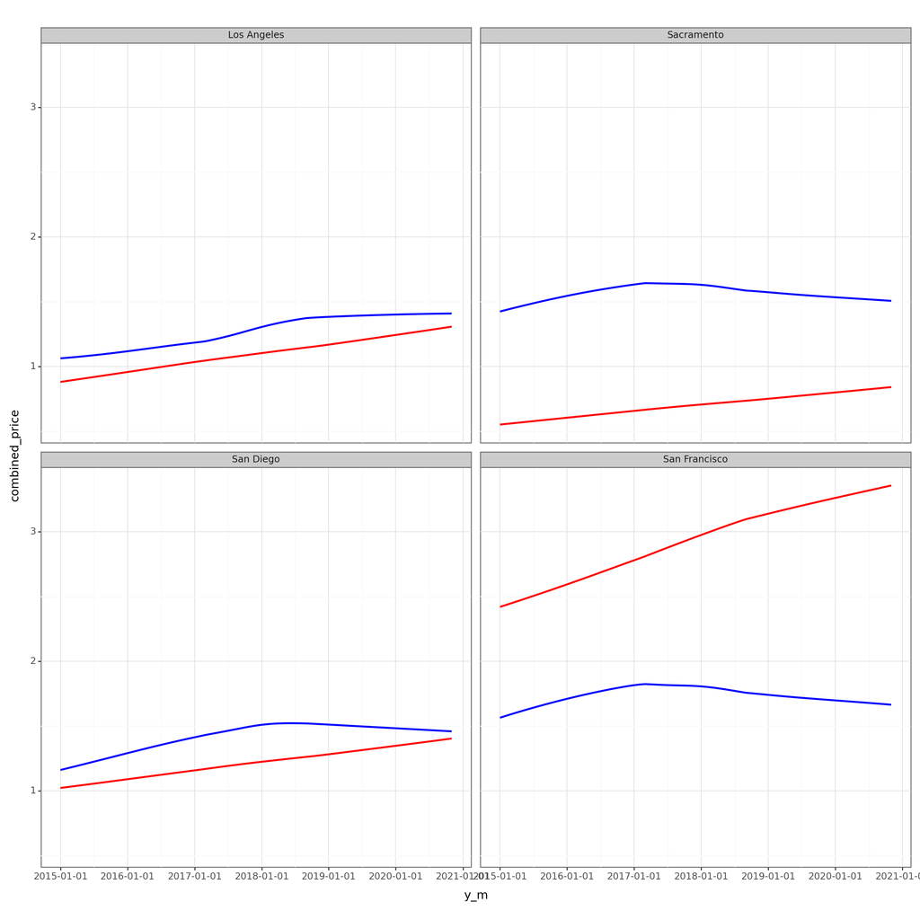

```
<Figure Size: (1200 x 1200)>
```

```python
(ggplot(avocado_cali_out) +
     theme_bw() +
     facet_wrap('geography') +
     geom_smooth(aes(x = 'y_m', y = 'combined_price'), color = 'blue') +
     geom_smooth(aes(x = 'y_m', y = 'home_price'), color = 'red', ) +
     theme(figure_size = (12,12))
)
```